# Zip Competition

Jingni Pang & Zhaoxin Zhang

GitHub Repository: https://github.com/ZZhang727/Pang_Zhang_ZIP

# Exective Summary

This report is written to record the process of using R to leverage this historical data (from January 2005 to June 2011) to forecast daily electricity demand for July 2011. We applied different models to forecast electricity demand in July 2010 and compared the forecasting results with the actual data to identify the most accurate model. The model using Prophet + TBATS had the best results. Therefore, we applied the Prophet + TBATS model to forecast electricity load in July 2011.

# Section 1: Data Wrangling

## 1.1 Import and Convert Data

Hourly electricity load data spanning January 2005 to June 2011 were used to forecast daily load for July 2011. As the raw data consist of 24 hourly observations per day, daily mean load values were computed by averaging across all hours within each calendar day, yielding a single daily aggregate series. The resulting series was then converted to a time series object for subsequent modeling.

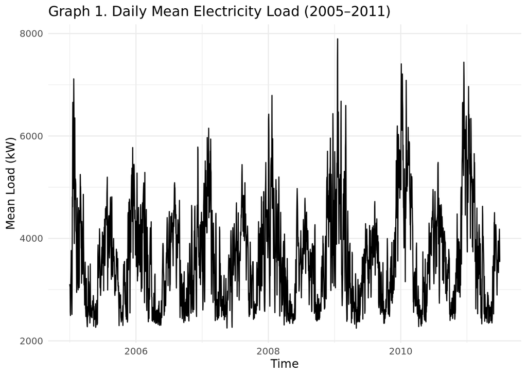

# 2. Methodology

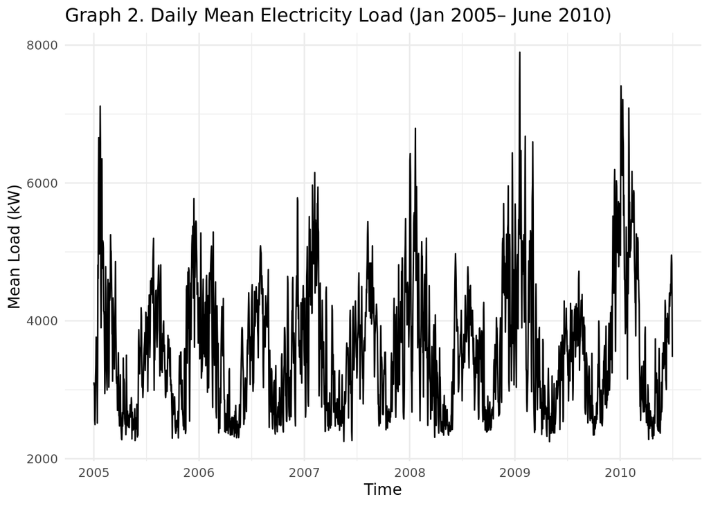

[figure not shown]